# Gaps in Care

Calum Nicholson

08/10/2020

```r
#import ACHD data
achd <- readRDS(file = paste(study_folder, 'output/rpah_analysis_dataset_2020-10-18.rds', sep=""))
```

## Selecting the sample to measure clinic engagement from

We will need to select a sample of patients from the ACHD database with a few requirements to ensure we can make a reasonable measure of clinic enagement:

```
__1. Timeframe needs to be taken from a point where clinic data has been measured consistently (i.e. retrospective data from before the database was set will not work well)__
```

The database was put together in 2012/2013 and you can see there are a lot of people with their first clinic visit around this time. This may be an artefact of data collection beginning rather than all of these patients being actually new. So we should exclude clinics before this time.

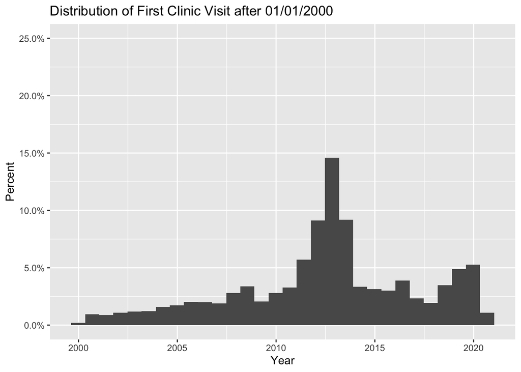

[output not shown]

```r
#Plot the distribution of the first clinic visit for each person in the dataset.
ggplot(achd, aes(x=first_clinic_2000)) +
      geom_histogram(aes( y = ..count../sum(..count..))) +
      scale_y_continuous(limits = c(0,0.25), labels = percent) +
      labs(title = "Distribution of First Clinic Visit after 01/01/2000",
           y = "Percent",
           x = "Year")
```

```r
# recreate the clinic level dataset
fup_2000 <- achd %>% select(achd_id, clinics_2000, death) %>% unnest(clinics_2000)
```

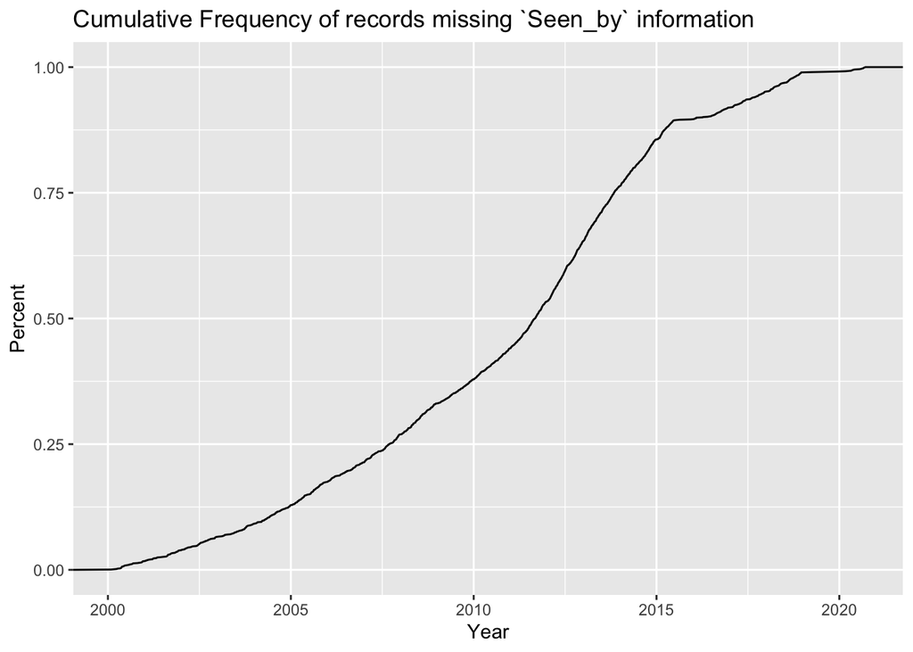

```r
# plot a cumulative frequency for the NA values in the seen_by variable
fup_2000 %>% select(clinic_date, seen_by) %>%
             arrange(clinic_date) %>%
             filter(is.na(seen_by)) %>%
             group_by(clinic_date) %>%
             summarise(n = n()) %>%
             ggplot(aes(x = clinic_date)) + stat_ecdf(geom = "line") +
             labs(title = "Cumulative Frequency of records missing `Seen_by` information",
             y = "Percent",
             x = "Year")
```

These two graphs suggests a sampling period of 01/01/2015 - 01/10/2020 (most recent clinic date is 17/09/2020)

```
  __3. Need to consider deaths in the sampling period__
```

We will need to filter for people who are alive throughout the sampling period, can use the "death’ variable for this

```r
# selecting patients still alive at 01/01/2015
achd %>% filter(death == 0) %>% head() %>% knitr::kable() %>%
  kableExtra::kable_styling()
```

[output not shown]

```
  __4. Make a distinctions between ACHD cardiology visits and other visits__
```

The `seen_by` variable has 7 levels: - “DC” - David Celermajer’s private ACHD clinic - “RC” - Rachael Cordina’s private ACHD clinic - “SHC” - Sydney Heart Centre’s ACHD clinic - “Outreach” - Rural ACHD clinics - “OtherCard” - Seen by another cardiologist - “Other” - Other Clinic - NA - missing

the DC, RC, SHC and Outreach are all counted as an “ACHD clinic” the others are a little harder to define. Each clinic also has a comment in `clinic_comment` that can provide some more information. A lot of the missing information that is still here can be attributed to ‘DC’, ‘RC’, or ‘SHC’ with the informaiton in the clinic comment

```r
fup_2000 %>% select(achd_id, clinic_date, clinic_comment, seen_by) %>%
             filter(clinic_date >= as.Date('01/01/2015', format='%d/%m/%Y')) %>%
             filter(seen_by == "OtherCard" | seen_by == "Other" | is.na(seen_by)) %>%
             head() %>%
             knitr::kable() %>%
             kableExtra::kable_styling()
```

| achd_id | clinic_date | clinic_comment | seen_by |
| --- | --- | --- | --- |
| 3152 | 2017-05-08 | DC ROOMS | NA |
| 3955 | 2017-11-23 | DC Rooms | NA |
| 24 | 2017-05-24 | letter from the patient | NA |
| 4106 | 2015-02-16 | DC Rooms | NA |
| 4106 | 2016-08-25 | DC Rooms | NA |
| 4106 | 2018-02-08 | DC Rooms | NA |

We will detect certain phrases from the clinic comment variable and assign those clinics to the correct category. After this process there are 70 clinics that are either `NA`, `OtherCard` or `Other`. Both `Other` and `OtherCard` don’t seem to be categorising clinics in any reliable fashion, so its probably best to exclude the rest of these clinics.

This leaves 5112 clinic records between 01/01/2015 and 01/10/2020, with patients seen at an ACHD clinics at RPAH (private, public or outreach) who are still alive.

```r
fup_filtered <- fup_2000  %>%
                # Select all clinics from 01/01/2015 to now
                filter(clinic_date >= as.Date('01/01/2015', format='%d/%m/%Y')) %>%
                # Clean some of the "seen_by" variable by detecting phrases in the clinic comments
                mutate(seen_by = replace(seen_by, str_detect(str_to_lower(clinic_comment), "dc.rooms"), "DC"),
                        seen_by = replace(seen_by, str_detect(str_to_lower(clinic_comment), "rc.rooms"), "RC"),
                        seen_by = replace(seen_by, str_detect(str_to_lower(clinic_comment), "dr rc private rooms"), "RC"),
                        seen_by = replace(seen_by, clinic_comment == "RC", "RC"),
                        seen_by = replace(seen_by, str_detect(clinic_comment, "SHC"), "SHC"),
                        seen_by = replace(seen_by, str_detect(str_to_lower(clinic_comment), "sydney heart centre"), "SHC"),
                        seen_by = replace(seen_by, str_detect(str_to_lower(clinic_comment), "achd clinic"), "SHC"),
                        seen_by = replace(seen_by, str_detect(clinic_comment, "Nowra"), "Outreach"),
                        seen_by = replace(seen_by, str_detect(clinic_comment, "Nowara"), "Outreach"),
                        seen_by = replace(seen_by, str_detect(clinic_comment, "Orange"), "Outreach"),
                        seen_by = replace(seen_by, str_detect(clinic_comment, "Canberra"), "Outreach"),
                        seen_by = replace(seen_by, seen_by == "OtherCard", NA),
                        seen_by = replace(seen_by, seen_by == "Other", NA),
                        ) %>%
                  # Remove clinic that are not RPAH ACHD clinic encounters and records from patients who passed away
                  filter(!is.na(seen_by)) %>% filter(death == 0) %>%
                  # Remove the death variable adter filtering
                  select(-death)
```

Have a look at the distribution of the clinic types

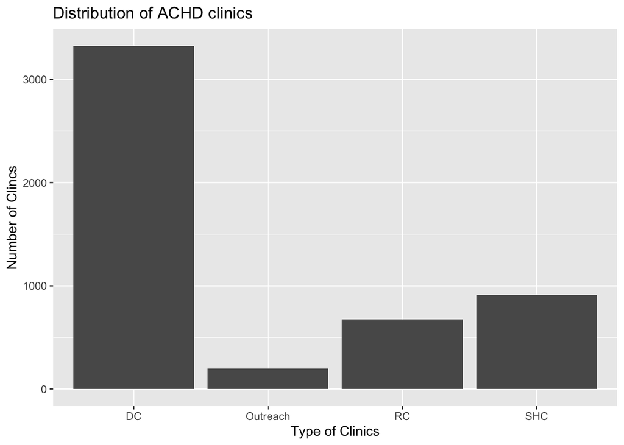

```r
ggplot(data = fup_filtered, aes(x = seen_by)) + geom_bar() +
             labs(title = "Distribution of ACHD clinics",
             y = "Number of Clincs",
             x = "Type of Clinics")
```

Add the filtered clinics back into the dataset

```r
achd.2 <- achd %>%
          select(-clinics, -no_clinics, -first_clinic, -last_clinic, -date_diff, -age_first_clinic, -age_last_clinic,
                 -clinics_2000, -no_clinics_2000, -first_clinic_2000, -last_clinic_2000, -date_diff_2000, -age_first_clinic_2000,
                 -age_last_clinic_2000) %>%
          nest_join(fup_filtered, by = 'achd_id') %>%
          mutate(
              # Number of clinics for each patient
              no_clinics = map_dbl(map(fup_filtered, ~ .$clinic_date), length)) %>%
          # filter patients with no clinic visits
          filter(no_clinics > 0) %>%
          mutate(
              # First clinic date for each patient
              first_clinic = as_date(map_dbl(fup_filtered, ~ min(.$clinic_date))),
              # Last clinic date for each patient
              last_clinic = as_date(map_dbl(fup_filtered, ~ max(.$clinic_date))),
              # Number of days between first and last clinic
              date_diff = as.duration(first_clinic %--% last_clinic) / dyears(1),
               )
```

*Number of Clinics*

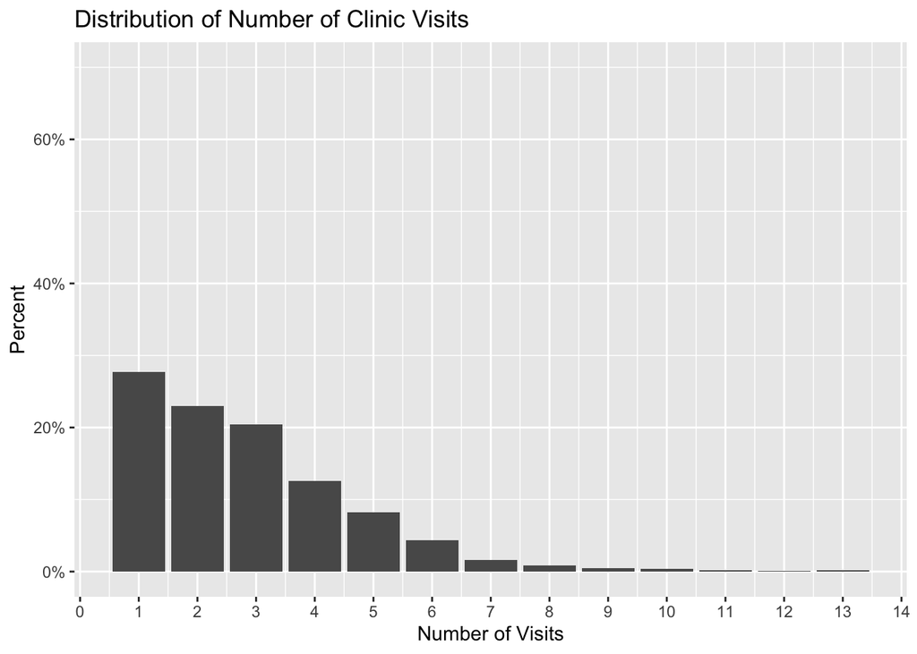

*First Clinic Date*

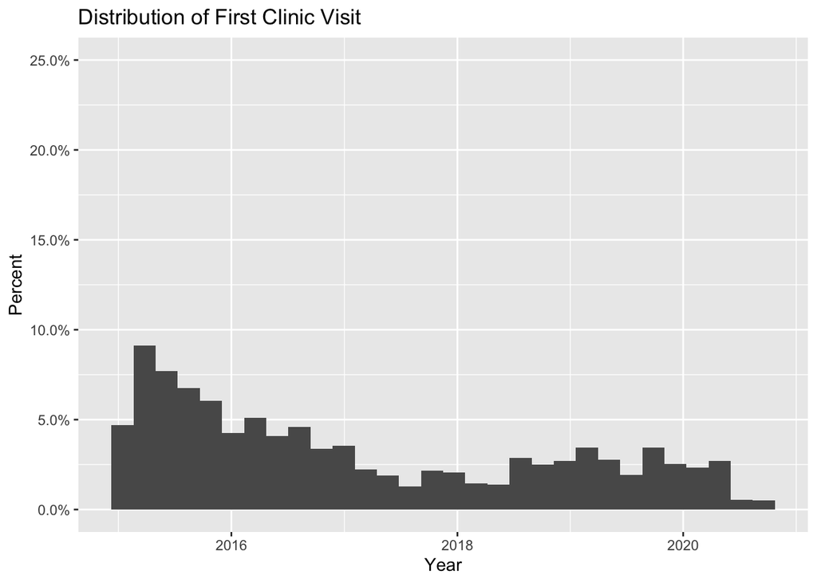

*Last Clinic Date*

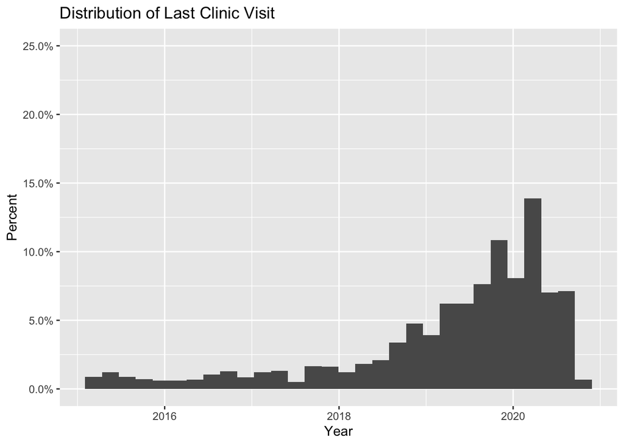

## Measuring Gaps in Clinics Visits

```r
#reminder of the 'clinics' data
achd.2 %>% filter(achd_id == 1101) %>% .$fup_filtered %>%
             knitr::kable() %>%
             kableExtra::kable_styling()
```

| clinic_date | clinic_comment | seen_by | outreach | new |
| --- | --- | --- | --- | --- |
| 2015-05-04 | SHC ACHD_DrRC_New | SHC | FALSE | TRUE |
| 2015-09-18 | SHC ACHD_DrRC | SHC | FALSE | FALSE |
| 2016-05-02 | SHC ACHD_DrRC | SHC | FALSE | FALSE |
| 2016-07-08 | SHC ACHD_DrRC | SHC | FALSE | FALSE |
| 2017-05-25 | SHC ACHD_DrRC | SHC | FALSE | FALSE |
| 2017-11-10 | SHC ACHD_DrRC | SHC | FALSE | FALSE |
| 2018-05-07 | SHC ACHD_DrRC | SHC | FALSE | FALSE |
| 2018-11-05 | SHC ACHD_DrRC | SHC | FALSE | FALSE |
| 2019-06-03 | SHC ACHD_DrRC | SHC | FALSE | FALSE |

```r
#use this as a test example
test <- achd.2 %>% filter(achd_id == 1101) %>% .$fup_filtered
test <- as.data.frame(test)
```

```r
test <- test %>%
                  # Calculate the time difference between each clinic visit in days
          mutate(gap = clinic_date - lag(clinic_date),
                  # Display the gap in years
                 gap_years = time_length(gap, "years"),
                  # Display the gap in months
                 gap_months = time_length(gap, 'months')
                 )

test %>%
             knitr::kable() %>%
             kableExtra::kable_styling()
```

| clinic_date | clinic_comment | seen_by | outreach | new | gap | gap_years | gap_months |
| --- | --- | --- | --- | --- | --- | --- | --- |
| 2015-05-04 | SHC ACHD_DrRC_New | SHC | FALSE | TRUE | NA days | NA | NA |
| 2015-09-18 | SHC ACHD_DrRC | SHC | FALSE | FALSE | 137 days | 0.3750856 | 4.501027 |
| 2016-05-02 | SHC ACHD_DrRC | SHC | FALSE | FALSE | 227 days | 0.6214921 | 7.457905 |
| 2016-07-08 | SHC ACHD_DrRC | SHC | FALSE | FALSE | 67 days | 0.1834360 | 2.201232 |
| 2017-05-25 | SHC ACHD_DrRC | SHC | FALSE | FALSE | 321 days | 0.8788501 | 10.546201 |
| 2017-11-10 | SHC ACHD_DrRC | SHC | FALSE | FALSE | 169 days | 0.4626968 | 5.552361 |
| 2018-05-07 | SHC ACHD_DrRC | SHC | FALSE | FALSE | 178 days | 0.4873374 | 5.848049 |
| 2018-11-05 | SHC ACHD_DrRC | SHC | FALSE | FALSE | 182 days | 0.4982888 | 5.979466 |
| 2019-06-03 | SHC ACHD_DrRC | SHC | FALSE | FALSE | 210 days | 0.5749487 | 6.899384 |

```r
# Calculate the average length of a gap in days
mean(test$gap, na.rm = TRUE)
```

```
## Time difference of 186.375 days
```

```r
# Calculate the standard deviation of the gaps in days
sd(test$gap, na.rm = TRUE)
```

```
## [1] 73.10645
```

```r
# Calculate the longest gap in days
max(test$gap, na.rm = TRUE)
```

```
## Time difference of 321 days
```

```r
# Calculate the number of gaps longer than 6 months
sum(test$gap_months > 6, na.rm = TRUE)
```

```
## [1] 3
```

```r
# Calculate the gaps for each patient
achd.2 <- achd.2 %>%
            mutate(fup_filtered = map(fup_filtered,
                                 ~ mutate(.x,
                                          # Calculate the time difference between each clinic visit in days
                                          gap = clinic_date - lag(clinic_date),
                                          # Display the gap in years
                                          gap_years = time_length(gap, "years"),
                                          # Display the gap in months
                                          gap_months = time_length(gap, "months")
                                          )),
                   # Calculate the longest gap in days
                   max_gap = map_dbl(fup_filtered, ~ max(.$gap,na.rm = TRUE)),
                   # Calculate the average length of a gap in days
                   mean_gap = map_dbl(fup_filtered, ~ mean(.$gap, na.rm = TRUE)),
                   # Calculate the standard deviation of the gaps in days
                   sd_gap = map_dbl(fup_filtered, ~ sd(.$gap, na.rm = TRUE)),
                   # Calculate the number of gaps longer than 3 months
                   gap_3m = map_dbl(fup_filtered, ~ sum(.$gap_months > 3, na.rm = TRUE)),
                   # Calculate the number of gaps longer than 6 months
                   gap_6m = map_dbl(fup_filtered, ~ sum(.$gap_months > 6, na.rm = TRUE)),
                   # Calculate the number of gaps longer than 1 year
                   gap_1yr = map_dbl(fup_filtered, ~ sum(.$gap_years > 1, na.rm = TRUE)),
                   # Calculate the number of gaps longer than 2 years
                   gap_2yr = map_dbl(fup_filtered, ~ sum(.$gap_years > 2, na.rm = TRUE)),
                   # Calculate the number of gaps longer than 3 years
                   gap_3yr = map_dbl(fup_filtered, ~ sum(.$gap_years > 3, na.rm = TRUE)),
                   )
```

```r
achd.2 %>% filter(achd_id == 1101) %>%
           .$fup_filtered %>%
           as.data.frame() %>%
             knitr::kable() %>%
             kableExtra::kable_styling()
```

| clinic_date | clinic_comment | seen_by | outreach | new | gap | gap_years | gap_months |
| --- | --- | --- | --- | --- | --- | --- | --- |
| 2015-05-04 | SHC ACHD_DrRC_New | SHC | FALSE | TRUE | NA days | NA | NA |
| 2015-09-18 | SHC ACHD_DrRC | SHC | FALSE | FALSE | 137 days | 0.3750856 | 4.501027 |
| 2016-05-02 | SHC ACHD_DrRC | SHC | FALSE | FALSE | 227 days | 0.6214921 | 7.457905 |
| 2016-07-08 | SHC ACHD_DrRC | SHC | FALSE | FALSE | 67 days | 0.1834360 | 2.201232 |
| 2017-05-25 | SHC ACHD_DrRC | SHC | FALSE | FALSE | 321 days | 0.8788501 | 10.546201 |
| 2017-11-10 | SHC ACHD_DrRC | SHC | FALSE | FALSE | 169 days | 0.4626968 | 5.552361 |
| 2018-05-07 | SHC ACHD_DrRC | SHC | FALSE | FALSE | 178 days | 0.4873374 | 5.848049 |
| 2018-11-05 | SHC ACHD_DrRC | SHC | FALSE | FALSE | 182 days | 0.4982888 | 5.979466 |
| 2019-06-03 | SHC ACHD_DrRC | SHC | FALSE | FALSE | 210 days | 0.5749487 | 6.899384 |

```r
achd.2 %>% filter(no_clinics > 5) %>%
            select(achd_id, bethesda_code, no_clinics, max_gap, mean_gap, sd_gap,
                   gap_3m, gap_6m, gap_1yr, gap_1yr, gap_2yr, gap_3yr) %>%
            head() %>%
             knitr::kable() %>%
             kableExtra::kable_styling()
```

| achd_id | bethesda_code | no_clinics | max_gap | mean_gap | sd_gap | gap_3m | gap_6m | gap_1yr | gap_2yr | gap_3yr |
| --- | --- | --- | --- | --- | --- | --- | --- | --- | --- | --- |
| 2212 | 3 | 6 | 403 | 249.20000 | 144.350961 | 4 | 4 | 2 | 0 | 0 |
| 3048 | 3 | 7 | 196 | 187.83333 | 6.882345 | 6 | 3 | 0 | 0 | 0 |
| 1889 | 1 | 8 | 290 | 278.00000 | 11.150486 | 7 | 7 | 0 | 0 | 0 |
| 2019 | 2 | 6 | 448 | 399.00000 | 35.064227 | 5 | 5 | 5 | 0 | 0 |
| 3994 | 1 | 6 | 630 | 375.80000 | 162.868659 | 5 | 4 | 1 | 0 | 0 |
| 4723 | 2 | 7 | 144 | 75.83333 | 51.207096 | 3 | 0 | 0 | 0 | 0 |

## Measuring Visit Constancy

This measure will divide the time period of interest into smaller time periods (we will use 6 months for the first test) and counts the number of periods with at least 1 visit. Measure will display as a percentage of the number of period with a visit, by the number of total periods.

```r
#revist our test patient 1101
achd.test <- achd.2 %>% filter(achd_id == 1101) %>% select (first_clinic, last_clinic, fup_filtered)

achd.test %>% knitr::kable() %>%
             kableExtra::kable_styling()
```

| first_clinic | last_clinic | fup_filtered |
| --- | --- | --- |
| 2015-05-04 | 2019-06-03 | 1.655900e+04, 1.669600e+04, 1.692300e+04, 1.699000e+04, 1.731100e+04, 1.748000e+04, 1.765800e+04, 1.784000e+04, 1.805000e+04, 1.003000e+03, 1.002000e+03, 1.002000e+03, 1.002000e+03, 1.002000e+03, 1.00… |

```r
achd.test.clinics <- achd.test %>% .$fup_filtered
achd.test.clinics <- as.data.frame(achd.test.clinics)
achd.test.clinics %>%
             knitr::kable() %>%
             kableExtra::kable_styling()
```

| clinic_date | clinic_comment | seen_by | outreach | new | gap | gap_years | gap_months |
| --- | --- | --- | --- | --- | --- | --- | --- |
| 2015-05-04 | SHC ACHD_DrRC_New | SHC | FALSE | TRUE | NA days | NA | NA |
| 2015-09-18 | SHC ACHD_DrRC | SHC | FALSE | FALSE | 137 days | 0.3750856 | 4.501027 |
| 2016-05-02 | SHC ACHD_DrRC | SHC | FALSE | FALSE | 227 days | 0.6214921 | 7.457905 |
| 2016-07-08 | SHC ACHD_DrRC | SHC | FALSE | FALSE | 67 days | 0.1834360 | 2.201232 |
| 2017-05-25 | SHC ACHD_DrRC | SHC | FALSE | FALSE | 321 days | 0.8788501 | 10.546201 |
| 2017-11-10 | SHC ACHD_DrRC | SHC | FALSE | FALSE | 169 days | 0.4626968 | 5.552361 |
| 2018-05-07 | SHC ACHD_DrRC | SHC | FALSE | FALSE | 178 days | 0.4873374 | 5.848049 |
| 2018-11-05 | SHC ACHD_DrRC | SHC | FALSE | FALSE | 182 days | 0.4982888 | 5.979466 |
| 2019-06-03 | SHC ACHD_DrRC | SHC | FALSE | FALSE | 210 days | 0.5749487 | 6.899384 |

**creating the interval of interest and dividing it into 6 month periods**

We want to divide each year into 6 month periods, based off the first and last clinic date.

```r
# find the 6 month date, before the first clinic date
start <- floor_date(achd.test$first_clinic, unit = "6 months")
# find the 6 month date, after the last clinic date
end <- ceiling_date(achd.test$last_clinic, unit = "6 months")
# break the period up into 6 month periods
breaks <- seq(start, end, "6 months")
# create intervals between each break
intervals <- interval(breaks, lead(breaks))
# remove the last interval with the NA value
intervals <- intervals[-length(intervals)]

intervals
```

```
## [1] 2015-01-01 UTC--2015-07-01 UTC 2015-07-01 UTC--2016-01-01 UTC
## [3] 2016-01-01 UTC--2016-07-01 UTC 2016-07-01 UTC--2017-01-01 UTC
## [5] 2017-01-01 UTC--2017-07-01 UTC 2017-07-01 UTC--2018-01-01 UTC
## [7] 2018-01-01 UTC--2018-07-01 UTC 2018-07-01 UTC--2019-01-01 UTC
## [9] 2019-01-01 UTC--2019-07-01 UTC
```

**Check whether there is a clinic visit within each 6 month period, and calculate the percentage of intervals with visits in them**

```r
# Clinic dates for the test patients
dates <- achd.test.clinics$clinic_date


# create a vector for testing the visits
visit_vector = vector(,length(intervals))

# Check whether any of the dates fall within each interval
for ( i in seq(length(intervals)) ) {
  visit_vector[i] <- any(dates %within% intervals[i])
}

#calculate the visit constancy
visit_constancy <- percent( sum(visit_vector) / length(visit_vector) )
visit_vector
```

```
## [1] TRUE TRUE TRUE TRUE TRUE TRUE TRUE TRUE TRUE
```

```r
visit_constancy
```

```
## [1] "100%"
```

```r
# Make a function for creating the interval periods
create.intervals <- function(start, end, period) {
            # break the period up into 6 month periods
            breaks <- seq(floor_date(start, unit = period), ceiling_date(end, unit = period), by = period)
            # create intervals between each break
            intervals <- interval(breaks, lead(breaks))
            # remove the last interval with the NA value
            intervals <- intervals[-length(intervals)]
            intervals
            }

#test with the same sample dates
create.intervals(achd.test$first_clinic, achd.test$last_clinic, "6 months")
```

```
## [1] 2015-01-01 UTC--2015-07-01 UTC 2015-07-01 UTC--2016-01-01 UTC
## [3] 2016-01-01 UTC--2016-07-01 UTC 2016-07-01 UTC--2017-01-01 UTC
## [5] 2017-01-01 UTC--2017-07-01 UTC 2017-07-01 UTC--2018-01-01 UTC
## [7] 2018-01-01 UTC--2018-07-01 UTC 2018-07-01 UTC--2019-01-01 UTC
## [9] 2019-01-01 UTC--2019-07-01 UTC
```

```r
# Make a function for calculating the visit constancy
calc.visit.constancy <- function(dates, intervals) {
            # create a vector for testing the visits
            visit_vector = vector(,length(intervals))
            # Check whether any of the dates fall within each interval
            for ( i in seq(length(intervals)) ) {
                          visit_vector[i] <- any(dates %within% intervals[i])
            }
            #calculate the visit constancy
            visit_constancy <- percent( sum(visit_vector) / length(visit_vector) )
            visit_constancy
            }

#test with the sample dates
calc.visit.constancy(achd.test.clinics$clinic_date,
                     create.intervals(achd.test$first_clinic, achd.test$last_clinic, "6 months"))
```

```
## [1] "100%"
```

Test the visit constancy measure with some other examples, see if we can find something that doesn’t equal 100%

```r
#test patient 2019
achd.test <- achd.2 %>% filter(achd_id == 2019) %>% select (first_clinic, last_clinic, fup_filtered)
achd.test.clinics <- achd.test %>% .$fup_filtered
achd.test.clinics <- as.data.frame(achd.test.clinics)
```

```r
#the clinic dates
achd.test.clinics$clinic_date
```

```
## [1] "2015-02-19" "2016-03-10" "2017-03-16" "2018-03-19" "2019-05-16"
## [6] "2020-08-06"
```

```r
#the intervals
as.data.frame(create.intervals(achd.test$first_clinic, achd.test$last_clinic, "6 months"))
```

```
##    create.intervals(achd.test$first_clinic, achd.test$last_clinic, "6 months")
## 1                                               2015-01-01 UTC--2015-07-01 UTC
## 2                                               2015-07-01 UTC--2016-01-01 UTC
## 3                                               2016-01-01 UTC--2016-07-01 UTC
## 4                                               2016-07-01 UTC--2017-01-01 UTC
## 5                                               2017-01-01 UTC--2017-07-01 UTC
## 6                                               2017-07-01 UTC--2018-01-01 UTC
## 7                                               2018-01-01 UTC--2018-07-01 UTC
## 8                                               2018-07-01 UTC--2019-01-01 UTC
## 9                                               2019-01-01 UTC--2019-07-01 UTC
## 10                                              2019-07-01 UTC--2020-01-01 UTC
## 11                                              2020-01-01 UTC--2020-07-01 UTC
## 12                                              2020-07-01 UTC--2021-01-01 UTC
```

```r
#test with the sample dates
calc.visit.constancy(achd.test.clinics$clinic_date,
                     create.intervals(achd.test$first_clinic, achd.test$last_clinic, "6 months"))
```

```
## [1] "50%"
```

```r
#test patient 1889
achd.test <- achd.2 %>% filter(achd_id == 1889) %>% select (first_clinic, last_clinic, fup_filtered)
achd.test.clinics <- achd.test %>% .$fup_filtered
achd.test.clinics <- as.data.frame(achd.test.clinics)
```

```r
#the clinic dates
achd.test.clinics$clinic_date
```

```
## [1] "2015-05-07" "2016-02-11" "2016-11-17" "2017-08-24" "2018-05-24"
## [6] "2019-02-04" "2019-11-21" "2020-09-03"
```

```r
#the intervals
as.data.frame(create.intervals(achd.test$first_clinic, achd.test$last_clinic, "6 months"))
```

```
##    create.intervals(achd.test$first_clinic, achd.test$last_clinic, "6 months")
## 1                                               2015-01-01 UTC--2015-07-01 UTC
## 2                                               2015-07-01 UTC--2016-01-01 UTC
## 3                                               2016-01-01 UTC--2016-07-01 UTC
## 4                                               2016-07-01 UTC--2017-01-01 UTC
## 5                                               2017-01-01 UTC--2017-07-01 UTC
## 6                                               2017-07-01 UTC--2018-01-01 UTC
## 7                                               2018-01-01 UTC--2018-07-01 UTC
## 8                                               2018-07-01 UTC--2019-01-01 UTC
## 9                                               2019-01-01 UTC--2019-07-01 UTC
## 10                                              2019-07-01 UTC--2020-01-01 UTC
## 11                                              2020-01-01 UTC--2020-07-01 UTC
## 12                                              2020-07-01 UTC--2021-01-01 UTC
```

```r
#test with the sample dates
calc.visit.constancy(achd.test.clinics$clinic_date,
                     create.intervals(achd.test$first_clinic, achd.test$last_clinic, "6 months"))
```

```
## [1] "67%"
```

```r
#test patient 3048
achd.test <- achd.2 %>% filter(achd_id == 3048) %>% select (first_clinic, last_clinic, fup_filtered)
achd.test.clinics <- achd.test %>% .$fup_filtered
achd.test.clinics <- as.data.frame(achd.test.clinics)
```

```r
#the clinic dates
achd.test.clinics$clinic_date
```

```
## [1] "2015-04-02" "2015-10-15" "2016-04-21" "2016-10-20" "2017-05-04"
## [6] "2017-11-02" "2018-05-03"
```

```r
#the intervals
as.data.frame(create.intervals(achd.test$first_clinic, achd.test$last_clinic, "6 months"))
```

```
##   create.intervals(achd.test$first_clinic, achd.test$last_clinic, "6 months")
## 1                                              2015-01-01 UTC--2015-07-01 UTC
## 2                                              2015-07-01 UTC--2016-01-01 UTC
## 3                                              2016-01-01 UTC--2016-07-01 UTC
## 4                                              2016-07-01 UTC--2017-01-01 UTC
## 5                                              2017-01-01 UTC--2017-07-01 UTC
## 6                                              2017-07-01 UTC--2018-01-01 UTC
## 7                                              2018-01-01 UTC--2018-07-01 UTC
```

```r
#test with the sample dates
calc.visit.constancy(achd.test.clinics$clinic_date,
                     create.intervals(achd.test$first_clinic, achd.test$last_clinic, "6 months"))
```

```
## [1] "100%"
```

```r
#test patient 3994
achd.test <- achd.2 %>% filter(achd_id == 3994) %>% select (first_clinic, last_clinic, fup_filtered)
achd.test.clinics <- achd.test %>% .$fup_filtered
achd.test.clinics <- as.data.frame(achd.test.clinics)
```

```r
#the clinic dates
achd.test.clinics$clinic_date
```

```
## [1] "2015-01-16" "2015-07-10" "2016-07-08" "2017-06-19" "2019-03-11"
## [6] "2020-03-09"
```

```r
#the intervals
as.data.frame(create.intervals(achd.test$first_clinic, achd.test$last_clinic, "2 years"))
```

```
##   create.intervals(achd.test$first_clinic, achd.test$last_clinic, "2 years")
## 1                                             2014-01-01 UTC--2016-01-01 UTC
## 2                                             2016-01-01 UTC--2018-01-01 UTC
## 3                                             2018-01-01 UTC--2020-01-01 UTC
## 4                                             2020-01-01 UTC--2022-01-01 UTC
```

```r
#test with the sample dates
calc.visit.constancy(achd.test.clinics$clinic_date,
                     create.intervals(achd.test$first_clinic, achd.test$last_clinic, "2 years"))
```

```
## [1] "100%"
```

```r
achd.2 <- achd.2 %>%
              mutate(interval_start_3m = floor_date(first_clinic, unit = "3 months"),
                     interval_end_3m = ceiling_date(last_clinic, unit = "3 months"),
                     vc_3m = map(fup_filtered, ~ calc.visit.constancy(.$clinic_date,
                                                                          create.intervals(.$clinic_date[1],
                                                                                           .$clinic_date[length(.$clinic_date)],
                                                                                           "3 months"))),
                     interval_start_6m = floor_date(first_clinic, unit = "6 months"),
                     interval_end_6m = ceiling_date(last_clinic, unit = "6 months"),
                     vc_6m = map(fup_filtered, ~ calc.visit.constancy(.$clinic_date,
                                                                          create.intervals(.$clinic_date[1],
                                                                                           .$clinic_date[length(.$clinic_date)],
                                                                                           "6 months"))),
                     interval_start_1yr = floor_date(first_clinic, unit = "1 year"),
                     interval_end_1yr = ceiling_date(last_clinic, unit = "1 year"),
                     vc_1yr = map(fup_filtered, ~ calc.visit.constancy(.$clinic_date,
                                                                          create.intervals(.$clinic_date[1],
                                                                                           .$clinic_date[length(.$clinic_date)],
                                                                                           "1 year"))),
                     interval_start_2yr = floor_date(first_clinic, unit = "2 years"),
                     interval_end_2yr = ceiling_date(last_clinic, unit = "2 years"),
                     vc_2yr = map(fup_filtered, ~ calc.visit.constancy(.$clinic_date,
                                                                          create.intervals(.$clinic_date[1],
                                                                                           .$clinic_date[length(.$clinic_date)],
                                                                                           "2 years"))),
                     interval_start_3yr = floor_date(first_clinic, unit = "3 years"),
                     interval_end_3yr = ceiling_date(last_clinic, unit = "3 years"),
                     vc_3yr = map(fup_filtered, ~ calc.visit.constancy(.$clinic_date,
                                                                          create.intervals(.$clinic_date[1],
                                                                                           .$clinic_date[length(.$clinic_date)],
                                                                                           "3 years"))),
                     )
```

```r
achd.2 %>% filter(no_clinics > 5) %>%
            select(achd_id, bethesda_code, no_clinics, first_clinic, last_clinic,
                   gap_3m, vc_3m, gap_6m, vc_6m, gap_1yr, vc_1yr, gap_2yr, vc_2yr, gap_3yr, vc_3yr) %>%
             knitr::kable() %>%
             kableExtra::kable_styling()
```

| achd_id | bethesda_code | no_clinics | first_clinic | last_clinic | gap_3m | vc_3m | gap_6m | vc_6m | gap_1yr | vc_1yr | gap_2yr | vc_2yr | gap_3yr | vc_3yr |
| --- | --- | --- | --- | --- | --- | --- | --- | --- | --- | --- | --- | --- | --- | --- |
| 2212 | 3 | 6 | 2015-05-28 | 2018-10-25 | 4 | 40% | 4 | 62% | 2 | 100% | 0 | 100% | 0 | 100% |
| 3048 | 3 | 7 | 2015-04-02 | 2018-05-03 | 6 | 54% | 3 | 100% | 0 | 100% | 0 | 100% | 0 | 100% |
| 1889 | 1 | 8 | 2015-05-07 | 2020-09-03 | 7 | 36% | 7 | 67% | 0 | 100% | 0 | 100% | 0 | 100% |
| 2019 | 2 | 6 | 2015-02-19 | 2020-08-06 | 5 | 26% | 5 | 50% | 5 | 100% | 0 | 100% | 0 | 100% |
| 3994 | 1 | 6 | 2015-01-16 | 2020-03-09 | 5 | 29% | 4 | 55% | 1 | 83% | 0 | 100% | 0 | 100% |
| 4723 | 2 | 7 | 2018-09-24 | 2019-12-23 | 3 | 100% | 0 | 100% | 0 | 100% | 0 | 100% | 0 | 100% |
| 924 | 3 | 6 | 2016-08-01 | 2019-10-25 | 5 | 43% | 1 | 57% | 1 | 75% | 0 | 100% | 0 | 100% |
| 4001 | 3 | 7 | 2015-02-09 | 2020-07-09 | 5 | 30% | 4 | 58% | 2 | 83% | 1 | 100% | 0 | 100% |
| 4166 | 2 | 6 | 2015-02-26 | 2020-09-03 | 5 | 26% | 5 | 50% | 2 | 83% | 0 | 100% | 0 | 100% |
| 2435 | 3 | 9 | 2015-01-16 | 2020-02-06 | 5 | 33% | 5 | 55% | 2 | 100% | 0 | 100% | 0 | 100% |
| 1066 | 2 | 6 | 2015-06-12 | 2020-03-09 | 5 | 30% | 5 | 55% | 1 | 100% | 0 | 100% | 0 | 100% |
| 277 | 2 | 6 | 2015-03-12 | 2020-03-12 | 5 | 29% | 4 | 55% | 4 | 83% | 0 | 100% | 0 | 100% |
| 2408 | 3 | 6 | 2016-10-14 | 2019-11-04 | 3 | 38% | 1 | 57% | 1 | 75% | 0 | 100% | 0 | 100% |
| 1592 | 2 | 10 | 2016-03-10 | 2020-09-10 | 5 | 47% | 4 | 70% | 2 | 100% | 0 | 100% | 0 | 100% |
| 1250 | 3 | 6 | 2015-02-19 | 2019-09-16 | 5 | 32% | 3 | 60% | 2 | 80% | 1 | 100% | 0 | 100% |
| 1473 | 1 | 6 | 2015-10-19 | 2018-06-28 | 4 | 55% | 3 | 83% | 1 | 100% | 0 | 100% | 0 | 100% |
| 4386 | 1 | 6 | 2016-03-10 | 2020-09-17 | 5 | 32% | 4 | 60% | 2 | 80% | 0 | 100% | 0 | 100% |
| 1134 | 3 | 9 | 2015-02-05 | 2020-07-09 | 7 | 39% | 5 | 67% | 4 | 100% | 0 | 100% | 0 | 100% |
| 2921 | 2 | 8 | 2015-02-12 | 2020-05-14 | 6 | 32% | 5 | 55% | 3 | 100% | 0 | 100% | 0 | 100% |
| 3243 | 3 | 7 | 2015-01-19 | 2020-09-10 | 6 | 30% | 6 | 58% | 4 | 100% | 0 | 100% | 0 | 100% |
| 4915 | 3 | 8 | 2019-04-18 | 2020-05-04 | 0 | 100% | 0 | 100% | 0 | 100% | 0 | 100% | 0 | 100% |
| 1195 | 3 | 6 | 2015-10-29 | 2020-03-06 | 5 | 33% | 2 | 60% | 1 | 83% | 0 | 100% | 0 | 100% |
| 916 | 3 | 11 | 2015-07-10 | 2020-03-16 | 7 | 53% | 5 | 80% | 0 | 100% | 0 | 100% | 0 | 100% |
| 2632 | 3 | 6 | 2015-08-13 | 2019-09-19 | 5 | 35% | 4 | 67% | 2 | 100% | 0 | 100% | 0 | 100% |
| 978 | 2 | 9 | 2015-02-26 | 2020-09-10 | 7 | 35% | 6 | 67% | 1 | 83% | 0 | 100% | 0 | 100% |
| 2864 | 3 | 7 | 2015-11-13 | 2018-04-06 | 2 | 55% | 1 | 67% | 1 | 75% | 0 | 100% | 0 | 100% |
| 996 | 3 | 8 | 2015-02-13 | 2019-03-11 | 7 | 47% | 4 | 89% | 0 | 100% | 0 | 100% | 0 | 100% |
| 987 | 2 | 6 | 2015-01-19 | 2020-05-07 | 5 | 27% | 5 | 55% | 4 | 83% | 0 | 100% | 0 | 100% |
| 1122 | 3 | 8 | 2015-04-23 | 2019-02-07 | 5 | 50% | 4 | 89% | 0 | 100% | 0 | 100% | 0 | 100% |
| 1217 | 3 | 6 | 2015-08-17 | 2019-10-24 | 4 | 33% | 4 | 56% | 2 | 100% | 0 | 100% | 0 | 100% |

[output cut: 114 more lines]